# Capstone

Torina Lewis

7/21/2019

Introduction In fall 2016, Clark Atlanta University (CAU)nevaluated student performance in lower-division courses in Academic Year (AY) 2012/13 to AY 2015/16; this review was then expanded to include AY 2016/17. There were high failure rates among students in 52.8% of these courses, which led to a review of courses in STEM. Foundational STEM courses include General Biology I & II, General Chemistry I & II; Programing Principles I; Calculus I, II, and III; and General and Modern Physics, and Mechanics. From this data, we noticed that approximately 30% of our STEM majors are earning a C in foundational STEM courses. We do not find this result acceptable and hope to provide resources to remedy this issue. Since mathematics is foundational for STEM courses, we aimed our Course Redesign with Technology (CRT) at improving student mastery of concepts in Calculus I.

A course redesign with the use of adaptive learning courseware began spring 2018 in the Department of Mathematical Sciences. The goal of the effort was to improve students’ mastery and the use of mathematical concepts through course redesign, assessment, and implementation using adaptive learning courseware which will enhance student mastery of learning outcomes, retention, and persistence rates in the undergraduate STEM degree programs at CAU. Calculus I was the selected course involved in the redesign and students occupied four sections of this course. Students in the course were divided into two groups. One section of the course was exposed (treatment group) to the intervention, the use of adaptive learning courseware, while the other students learned Calculus with previous teaching methods (control group). The courseware piloted in this course is Assessment and LEarning in Knowledge Spaces (ALEKS). The course product used was “Prep for Calculus,” a course that is designed to help students to develop the prerequisite foundation needed to learn Calculus I. We employ this product as a corequisite to support the Calculus I course.

The goal of this project is to determine the effectiveness of the intervention. After several meetings with my mentor, Dhiraj Khanna and learning the intricacies of the R ecosystem, I have decided to use propensity score matching to determine the effectiveness of the intervention. This statistical technique matches a treatment case with one or more control cases based on the propensity score. The propensity score is determined by the attributes that the observations have in common. A recommendation from my mentor was to include cognitive and non-cognitive variables in the study. The variables used are listed below:

Instructor - the person that taught the class Major - the student’s major area of study Grade - the letter grade that the student earned in the course Gender - the student’s self reported gender male = 1, female =0 Race - Black =1, Others = 0 1st Generation - The students that are the first to attend college. First = 0, Not the First to Attend College = 1 Score - The numeric grade that corresponds to the letter grade (90=A, 80=B, 70=C, 60=D, 50=F). Treatment - Determines the student group. Treatment =1, Control =0 Pell - The student is eligible to receive a grant from the federal government. Yes =1, No =0 Standardized Score - The standardized z-score for numeric grades.

The necessary libraries needed for the project has been installed and are loaded here.

```r
library(tidyverse) #The swiss knife!
#library(haven)
#library(sjmisc)
#library(plyr)
library(MatchIt)
#library(ggplot2)
#library(caret)
#library(RCurl) #To read the csv file from GitHub directly
library(rmarkdown)
```

All of the packages are loaded. Therefore, we load the data into R and call the data frame dta.

```r
dta <- read.csv("dta.csv")
```

```r
#dta<-select(dta, -c(X))
```

Data Wrangligling

The data set was provided in a nearly cleaned manner. However, multiple data wrangling techniques were performed on the data frame to transom it into a document that can be analyzed. These techniques include removing unnecessary variables, changing the names of some columns, adding variables, and including functions for calculation.

Changing Columns Names: There are ten variables included in the data frame, and all variables underwent a name change. When the data was imported into R Studio, some variables names were too long, and others did not accurately describe the particular data. Therefore, the names of the variables were changed to shorter, concise names that accurately describe the data in the column.

Adding Variables and Data: Two variables were necessary for building the model. A treatment column and a column that displayed standardized z scores for the final grade earned. In the treatment column, an if-else statement was written to place a 1 for the observation that was treated and a 0 otherwise. This information helped to accurately and easily determine the control and treatment groups.

Standardized z-score: In the standardized z-score column, a function was written to include a standardized score for each observation in the “Score” column of the data frame. This standardized z-score normalizes the data and has a mean of 0 and a standard deviation of 1. It represents the signed fractional number of standard deviations by which the value of an observation or data point lies above or below the mean value of the data set that is measured. Values above the mean have positive standard scores, while values below the mean have negative standard scores. Adding this column increased the data frame to 10 variables.

Exploratory Data Analysis Now that the data have been ingested it is time to begin the exploration. The first thing to do is to have a quick look at our data. For that, the `str()` function and the more human-readable (and intuitive), `glimpse()` function. is used.

```r
glimpse(dta)
```

```
## Observations: 332
## Variables: 11
## $ X               <int> 1, 2, 3, 4, 5, 6, 7, 8, 9, 10, 11, 12, 13, 14,...
## $ Instructor      <fct> "Kebede, Temesgen", "Whelchel, Noel", "Whelche...
## $ Major           <fct> Biology, Biology, Computer Science, Computer a...
## $ Grade           <fct> A, A, B, F, D, A, C, B, B, B, A, B, D, C, A, C...
## $ Gender          <int> 1, 1, 0, 0, 0, 0, 0, 1, 1, 1, 1, 1, 1, 1, 1, 1...
## $ Race            <int> 0, 0, 0, 0, 0, 0, 0, 1, 1, 1, 1, 1, 1, 1, 1, 1...
## $ Pell            <int> 0, 0, 0, 0, 0, 0, 0, 0, 0, 0, 0, 0, 0, 0, 0, 0...
## $ X1st.Generation <int> 0, 0, 0, 0, 0, 0, 0, 0, 0, 0, 0, 0, 0, 0, 0, 0...
## $ Score           <int> 90, 90, 80, 50, 60, 90, 70, 80, 80, 80, 90, 80...
## $ Treatment       <int> 0, 0, 0, 0, 0, 0, 0, 0, 0, 0, 0, 0, 0, 0, 0, 0...
## $ Std_Score       <dbl> 1.1725667, 1.1725667, 0.4489754, -1.7217987, -...
```

```r
str(dta)
```

```
## 'data.frame':    332 obs. of  11 variables:
##  $ X              : int  1 2 3 4 5 6 7 8 9 10 ...
##  $ Instructor     : Factor w/ 9 levels "Djire, Bakary",..: 5 9 9 5 1 1 3 1 8 6 ...
##  $ Major          : Factor w/ 20 levels "Accounting","Biology",..: 2 2 7 6 6 6 5 18 2 19 ...
##  $ Grade          : Factor w/ 5 levels "A","B","C","D",..: 1 1 2 5 4 1 3 2 2 2 ...
##  $ Gender         : int  1 1 0 0 0 0 0 1 1 1 ...
##  $ Race           : int  0 0 0 0 0 0 0 1 1 1 ...
##  $ Pell           : int  0 0 0 0 0 0 0 0 0 0 ...
##  $ X1st.Generation: int  0 0 0 0 0 0 0 0 0 0 ...
##  $ Score          : int  90 90 80 50 60 90 70 80 80 80 ...
##  $ Treatment      : int  0 0 0 0 0 0 0 0 0 0 ...
##  $ Std_Score      : num  1.173 1.173 0.449 -1.722 -0.998 ...
```

Evaluating the output for each code, it is easy to determine that the codes provide almost identical information.

Since propensity score matching aim is to group the data, the most apparent grouping of students., their major.

```r
library(tidyverse)
dta %>% group_by(Major) %>% count() %>% arrange(desc(n))
```

```
## # A tibble: 20 x 2
## # Groups:   Major [20]
##    Major                             n
##    <fct>                         <int>
##  1 Biology                         160
##  2 Computer Science                 40
##  3 Computer and Information Sys     29
##  4 Business Administration          25
##  5 Dual Deg Engineer - Physics      15
##  6 Chemistry                        13
##  7 Dual Deg Engineer- Comp Sci       9
##  8 Dual Deg Engineer - Chemistry     7
##  9 Psychology - BS Degree            7
## 10 Psychology                        6
## 11 Biology - Public Health           4
## 12 Accounting                        3
## 13 General Studies                   3
## 14 Criminal Justice Admin            2
## 15 Dual Degree-Biology               2
## 16 Mass Media Arts                   2
## 17 Mathematics                       2
## 18 Early Childhood Education         1
## 19 English                           1
## 20 Social Work                       1
```

The major with the largest number of students is Biology. This number is typical as the majority of STEM majors want to become doctors. Now consider those majors where the count is greater than five. Call this data frame major_count and print it to the console.

```r
major_count <- dta %>% group_by(Major) %>% count() %>% filter(n > 5)
major_count
```

```
## # A tibble: 10 x 2
## # Groups:   Major [10]
##    Major                             n
##    <fct>                         <int>
##  1 Biology                         160
##  2 Business Administration          25
##  3 Chemistry                        13
##  4 Computer and Information Sys     29
##  5 Computer Science                 40
##  6 Dual Deg Engineer- Comp Sci       9
##  7 Dual Deg Engineer - Chemistry     7
##  8 Dual Deg Engineer - Physics      15
##  9 Psychology                        6
## 10 Psychology - BS Degree            7
```

This filter seems to be a good one. Now take a deeper dive into the data to determine the grade by major. A comparison among majors by grade will provide pertinent information. The results will be displayed as a bar graph.

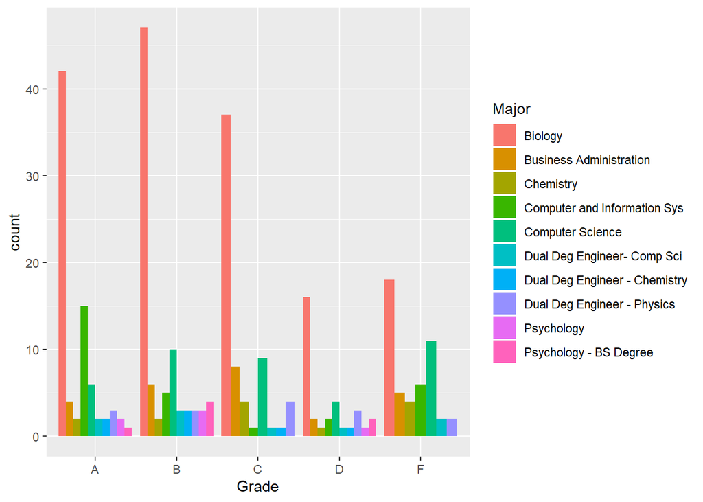

```r
ggplot(dta %>% filter(Major %in% unique(major_count$Major)),
       aes(x = Grade, fill = Major)) + geom_bar(position = 'dodge')
```

Shifting the focus to instructors, the workload of each instructor is determined.

```r
dta %>% group_by(Instructor) %>% count() %>%  arrange(desc(n))
```

```
## # A tibble: 9 x 2
## # Groups:   Instructor [9]
##   Instructor            n
##   <fct>             <int>
## 1 Lewis, Torina        53
## 2 Whelchel, Noel       53
## 3 Slaughter, Keenan    49
## 4 Parker, Cassandra    34
## 5 Djire, Bakary        33
## 6 Harlemon, Maxine     33
## 7 Kebede, Temesgen     30
## 8 Jackson, Calvin      24
## 9 Jalloh, Mohamed      23
```

What majors typically enroll in a professors course? Is this by chance or design? That is a question for the next project, but it is interesting to take a peak at least.

```r
inst_maj <- dta %>% group_by(Instructor, Major) %>% count() %>% arrange(desc(n))
inst_maj
```

```
## # A tibble: 80 x 3
## # Groups:   Instructor, Major [80]
##    Instructor        Major                            n
##    <fct>             <fct>                        <int>
##  1 Slaughter, Keenan Biology                         31
##  2 Whelchel, Noel    Biology                         28
##  3 Lewis, Torina     Biology                         27
##  4 Harlemon, Maxine  Biology                         22
##  5 Kebede, Temesgen  Biology                         17
##  6 Djire, Bakary     Biology                         11
##  7 Parker, Cassandra Biology                         10
##  8 Lewis, Torina     Computer Science                 9
##  9 Whelchel, Noel    Computer and Information Sys     9
## 10 Djire, Bakary     Computer and Information Sys     8
## # ... with 70 more rows
```

Since biology has more students enroll in the course than an other major, it is not surprising that professors teach a lot of biology students.

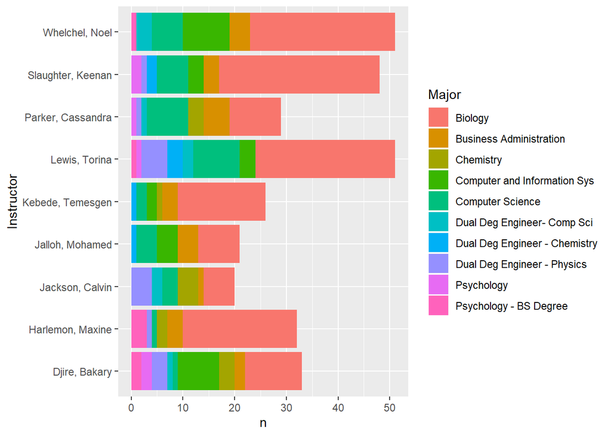

```r
ggplot(inst_maj %>% filter(Major %in% unique(major_count$Major)) , aes(x = Instructor, y = n, fill = Major)) + geom_bar(stat = 'identity') +
  coord_flip()
```

Shoveling deeper into extracting the truth from the data, consider the treatment and control groups number of majors.

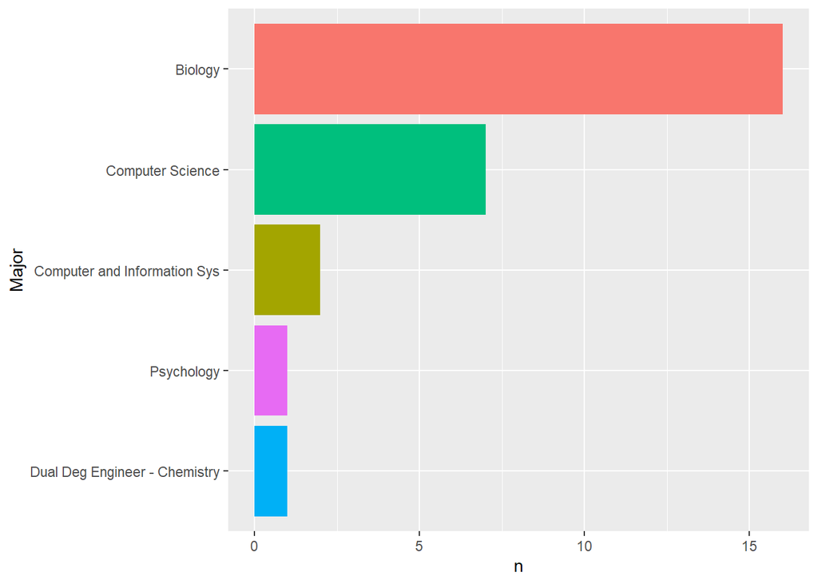

```r
dta %>% filter(Treatment == 1) %>% count(Major) %>%
  ggplot(aes(x = reorder(Major, n), y = n, fill = Major)) + geom_bar(stat = 'identity') + coord_flip() +
  xlab('Major') + theme(legend.position = "none")
```

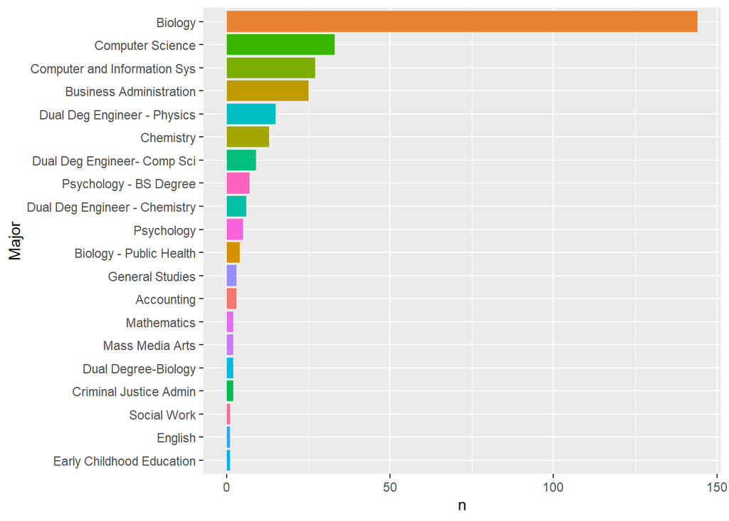

```r
dta %>% filter(Treatment == 0) %>% count(Major) %>%
  ggplot(aes(x = reorder(Major, n), y = n, fill = Major)) + geom_bar(stat = 'identity') + coord_flip() +
  xlab('Major') + theme(legend.position = "none")
```

Wow, the treatment group only includes five majors, and the control group contains every major in the data set. From this information, we filter only biology, computer science, computer information system, psychology, and dual deg engineering (chemistry) for additional analysis.

```r
dta_new <- filter(dta, Major == "Biology" | Major == "Psychology" | Major == "Computer and Information Sys" | Major == "Computer Science" | Major == "Dual Deg Engineer - Chemistry")
```

To ensure that the code above properly filtered the data, a simple table is coded to count the number of students in each major.

```r
major_count1 <- dta_new %>% group_by(Major) %>% count()
major_count1
```

```
## # A tibble: 5 x 2
## # Groups:   Major [5]
##   Major                             n
##   <fct>                         <int>
## 1 Biology                         160
## 2 Computer and Information Sys     29
## 3 Computer Science                 40
## 4 Dual Deg Engineer - Chemistry     7
## 5 Psychology                        6
```

One last piece of information is organized before statistical analysis are completed. That is, a the grades that the students earned in the treatment and the control groups. This information may spark more questions.

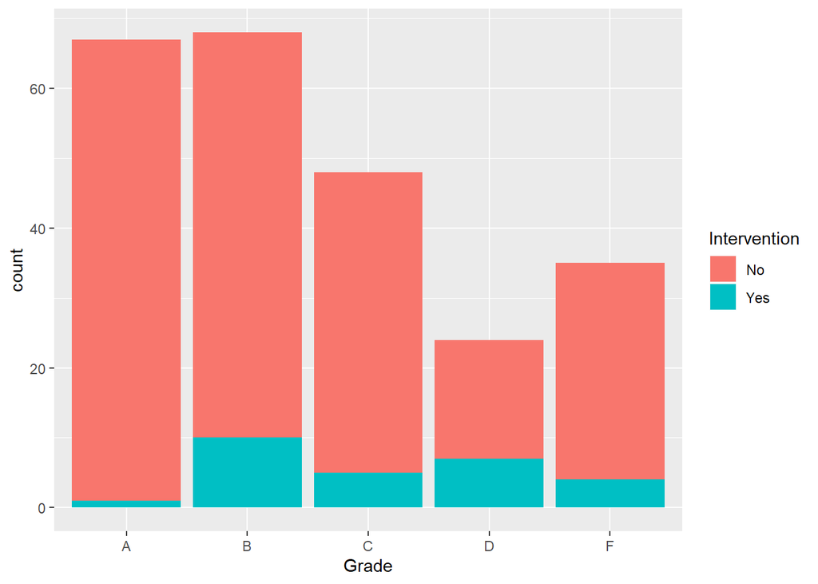

```r
dta_new$Intervention <- ifelse(dta_new$Treatment == 1, 'Yes', 'No')
ggplot(dta_new, aes(x = Grade, fill = Intervention)) + geom_bar()
```

Statistical Analysis Determine if there is a difference in means between the treatment and the control groups for the variables “Score and Std_Score.” These two values are equivalent, but there may be value in examining both.

```r
dta_new %>%
  dplyr::group_by(Treatment) %>%
  dplyr::summarise(n_students = n(),
            AvgScore = mean(Score),
            std_error = sd(Score) / sqrt(n_students))
```

```
## # A tibble: 2 x 4
##   Treatment n_students AvgScore std_error
##       <int>      <int>    <dbl>     <dbl>
## 1         0        215     75.2     0.939
## 2         1         27     68.9     2.29
```

```r
#Calculate the differences in means for the standardized score "Std_Score" grouping by treatment (1) and control (0) groups for the outcome variable.
dta_new %>%
  dplyr:: group_by(Treatment) %>%
  dplyr:: summarise(n_students = n(),
            AvgStdScore = mean(Std_Score),
            std_error = sd(Std_Score) / sqrt(n_students))
```

```
## # A tibble: 2 x 4
##   Treatment n_students AvgStdScore std_error
##       <int>      <int>       <dbl>     <dbl>
## 1         0        215      0.0990    0.0679
## 2         1         27     -0.355     0.165
```

There is definitely a difference in means, as shown in the tables. A t-test can provide further analysis. Compute a t.test to determine if the difference in means is statistically significant at conventional levels of confidence. If p is larger than 0.05, accept the null that the two means are equal. For a smaller p-value, more confidence is given when rejecting the null hypothesis. Again, the t-test will be completed twice, once for “Score” and another time for the “Std_Score” variable.

Recall: Null hypotheses - the mean of the two samples are equal.

```r
with(dta_new, t.test(Std_Score ~ Treatment))
```

```
##
##  Welch Two Sample t-test
##
## data:  Std_Score by Treatment
## t = 2.5392, df = 35.397, p-value = 0.01565
## alternative hypothesis: true difference in means is not equal to 0
## 95 percent confidence interval:
##  0.0911647 0.8167835
## sample estimates:
## mean in group 0 mean in group 1
##      0.09895908     -0.35501504
```

```r
with(dta_new, t.test(Score ~ Treatment))
```

```
##
##  Welch Two Sample t-test
##
## data:  Score by Treatment
## t = 2.5392, df = 35.397, p-value = 0.01565
## alternative hypothesis: true difference in means is not equal to 0
## 95 percent confidence interval:
##   1.259892 11.287912
## sample estimates:
## mean in group 0 mean in group 1
##        75.16279        68.88889
```

Just as anticipated, p < 0.05, and the null hypothesis is rejected. We continue the project by using the “MatchIt” package to completed the propensity score matching. We get help from the “MathcIt” package to view the user guide to help determine the best fit for the code.

```r
?matchit
```

```
## starting httpd help server ... done
```

The user guide can be found by seraching “matchit” in the packages tab in the video to the bottom left.

Now prepare for the highlight. Will the data be matched or not. It’s time to see. The code for matching the data is annotated in the console using “nearest” as the method for the “MatchIt” package. There are additional methods available with explanitations in the user guide. A summary of the matching model is printed, and a graphical depiction of the matched data is provided.

```r
library(MatchIt)
mod_match <- matchit(Treatment ~  Gender + Race + Pell + X1st.Generation,
                     method = 'nearest', data = dta_new)
summary(mod_match)
```

```
##
## Call:
## matchit(formula = Treatment ~ Gender + Race + Pell + X1st.Generation,
##     data = dta_new, method = "nearest")
##
## Summary of balance for all data:
##                 Means Treated Means Control SD Control Mean Diff eQQ Med
## distance               0.1179        0.1108     0.0269    0.0072       0
## Gender                 0.7407        0.6651     0.4731    0.0756       0
## Race                   0.9259        0.8605     0.3473    0.0655       0
## Pell                   0.6296        0.6558     0.4762   -0.0262       0
## X1st.Generation        0.2963        0.3070     0.4623   -0.0107       0
##                 eQQ Mean eQQ Max
## distance          0.0078  0.0338
## Gender            0.0741  1.0000
## Race              0.0741  1.0000
## Pell              0.0370  1.0000
## X1st.Generation   0.0000  0.0000
##
##
## Summary of balance for matched data:
##                 Means Treated Means Control SD Control Mean Diff eQQ Med
## distance               0.1179        0.1179     0.0254         0       0
## Gender                 0.7407        0.7407     0.4466         0       0
## Race                   0.9259        0.9259     0.2669         0       0
## Pell                   0.6296        0.6296     0.4921         0       0
## X1st.Generation        0.2963        0.2963     0.4653         0       0
##                 eQQ Mean eQQ Max
## distance               0       0
## Gender                 0       0
## Race                   0       0
## Pell                   0       0
## X1st.Generation        0       0
##
## Percent Balance Improvement:
##                 Mean Diff. eQQ Med eQQ Mean eQQ Max
## distance               100       0      100     100
## Gender                 100       0      100     100
## Race                   100       0      100     100
## Pell                   100       0      100     100
## X1st.Generation        100       0        0       0
##
## Sample sizes:
##           Control Treated
## All           215      27
## Matched        27      27
## Unmatched     188       0
## Discarded       0       0
```

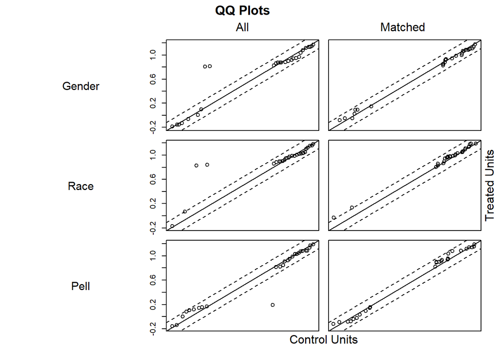

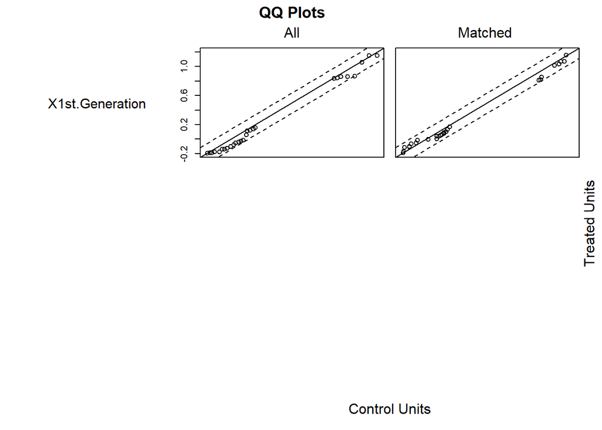

```r
plot(mod_match)
```

The first line of code creates an R data set that only contains the matched cases. The second line of data converts and saves the matched data set as a .csv file. It is just like saving a word document. Now the document can be opened on any device that read .csv files.

```r
mod_data <- match.data(mod_match)
write.csv(mod_data, file = "mod_data.csv")
```

The Results The results show that the matching worked well with the data set as all of the students in the treatment group were matched to a student in the control group. In the summary of balance for all data section of the table, before matching, there were slight differences in treated and control means. After matching, there was no difference in the means. The quartile (QQ) columns in these summary data show the median, mean, and maximum quartile between the treated and control data; smaller QQ values indicates better matching. Note that the QQ values were 0 after matching.

Examining Covariate Balance in the Matched Sample

```r
dta_cov <- c( "Race", "Pell", "X1st.Generation", "Gender")
mod_data %>%
  group_by(Treatment) %>%
  select(one_of(dta_cov)) %>%
  summarise_all(funs(mean))
```

```
## # A tibble: 2 x 5
##   Treatment  Race  Pell X1st.Generation Gender
##       <int> <dbl> <dbl>           <dbl>  <dbl>
## 1         0 0.926 0.630           0.296  0.741
## 2         1 0.926 0.630           0.296  0.741
```

The means below indicate that we have attained a high degree of balance on the four covariates includede in the model. A t-test is a more formal way of testing if the means differ,

```r
lapply(dta_cov, function(v) {
    t.test(mod_data[, v] ~ mod_data$Treatment)})
```

```
## [[1]]
##
##  Welch Two Sample t-test
##
## data:  mod_data[, v] by mod_data$Treatment
## t = 0, df = 52, p-value = 1
## alternative hypothesis: true difference in means is not equal to 0
## 95 percent confidence interval:
##  -0.145754  0.145754
## sample estimates:
## mean in group 0 mean in group 1
##       0.9259259       0.9259259
##
##
## [[2]]
##
##  Welch Two Sample t-test
##
## data:  mod_data[, v] by mod_data$Treatment
## t = 0, df = 52, p-value = 1
## alternative hypothesis: true difference in means is not equal to 0
## 95 percent confidence interval:
##  -0.2687571  0.2687571
## sample estimates:
## mean in group 0 mean in group 1
##       0.6296296       0.6296296
##
##
## [[3]]
##
##  Welch Two Sample t-test
##
## data:  mod_data[, v] by mod_data$Treatment
## t = 0, df = 52, p-value = 1
## alternative hypothesis: true difference in means is not equal to 0
## 95 percent confidence interval:
##  -0.2541308  0.2541308
## sample estimates:
## mean in group 0 mean in group 1
##       0.2962963       0.2962963
##
##
## [[4]]
##
##  Welch Two Sample t-test
##
## data:  mod_data[, v] by mod_data$Treatment
## t = 0, df = 52, p-value = 1
## alternative hypothesis: true difference in means is not equal to 0
## 95 percent confidence interval:
##  -0.2438931  0.2438931
## sample estimates:
## mean in group 0 mean in group 1
##       0.7407407       0.7407407
```

The results indicate that we fail to reject the null. Thus there is no difference in means between the covariates. An estimate of the effects of the resentment on each of the groups is easy once the data is matched.

```r
with(mod_data, t.test(Score ~ Treatment))
```

```
##
##  Welch Two Sample t-test
##
## data:  Score by Treatment
## t = 2.4092, df = 51.612, p-value = 0.01959
## alternative hypothesis: true difference in means is not equal to 0
## 95 percent confidence interval:
##   1.360366 14.935930
## sample estimates:
## mean in group 0 mean in group 1
##        77.03704        68.88889
```

The t-test reveals that there is a difference between the means. It appears that the control group outperformed the treatment group.

Machine Learning - Linear Regression

```r
lm_treat1 <- lm(Score ~ Race + Pell + X1st.Generation + Gender, data = mod_data)
summary(lm_treat1)
```

```
##
## Call:
## lm(formula = Score ~ Race + Pell + X1st.Generation + Gender,
##     data = mod_data)
##
## Residuals:
##     Min      1Q  Median      3Q     Max
## -24.643 -11.875   2.381   8.125  19.762
##
## Coefficients:
##                 Estimate Std. Error t value Pr(>|t|)
## (Intercept)       65.000      6.522   9.967 2.25e-13 ***
## Race               9.643      8.175   1.179    0.244
## Pell              -4.405      4.500  -0.979    0.333
## X1st.Generation   -1.339      4.773  -0.281    0.780
## Gender             2.976      4.930   0.604    0.549
## ---
## Signif. codes:  0 '***' 0.001 '**' 0.01 '*' 0.05 '.' 0.1 ' ' 1
##
## Residual standard error: 13.04 on 49 degrees of freedom
## Multiple R-squared:  0.06602,    Adjusted R-squared:  -0.01022
## F-statistic: 0.866 on 4 and 49 DF,  p-value: 0.4911
```

Recommendations 1. Try to use another intervention 2. Collect additional data on the students that can be used as possible variables that influence grades 3. Higher me fulltime

Future Work What will happen if the model is built for categorical values? Will the data stil be a perfect match? These are all questions availabe for fututre analysis. Building more efficient models and developing sound reasoning for selecting covariates for the models is an aspect that can enhance this project. Also conducting a follow-up analysis on the matched grouped to determine if the treatment had an impact on student achievement in Calculus I. Lastly, it is my goal to build a model that predicts final grades or final exam scores.